# EDA automático

Informe exploratorio generado a partir de parámetros

Autor/a

Fecha de publicación

15/11/2026

**NotaCómo usar este informe**

Este documento no se edita: se **parametriza**. Cambias el archivo y la variable respuesta, y se genera un EDA completo de cualquier dataset en formato CSV. En la **consola** de RStudio, con el proyecto abierto:

```r
quarto::quarto_render("analisis/eda_automatico.qmd",
  execute_params = list(archivo = "data/processed/mi_dataset.csv",
                        respuesta = "mi_variable", excluir = "id"))
```

El resultado es `analisis/eda_automatico.html`. Es un punto de partida, no un sustituto del EDA orientado a hipótesis: las **alertas** del final indican qué revisar y qué decisiones anotar en el registro.

**Código**

```r
library(tidyverse)
library(here)
library(corrplot)

datos <- read_csv(here(params$archivo), show_col_types = FALSE)
excluir <- trimws(strsplit(params$excluir, ",")[[1]])
datos <- select(datos, -any_of(excluir))
y <- params$respuesta
stopifnot("La variable respuesta no existe en el archivo" = y %in% names(datos))

num <- datos |> select(where(is.numeric), -any_of(y)) |> names()
cat_ <- datos |> select(where(~ is.character(.x) || is.factor(.x) || is.logical(.x)), -any_of(y)) |> names()
resp_categorica <- !is.numeric(datos[[y]]) || n_distinct(datos[[y]]) <= 10
if (resp_categorica) datos[[y]] <- factor(datos[[y]])
num_var <- num[sapply(num, function(v) isTRUE(sd(datos[[v]], na.rm = TRUE) > 0))]  # sin constantes
asimetria <- function(x) { x <- x[!is.na(x)]; mean((x - mean(x))^3) / sd(x)^3 }
```

## 1. Estructura

**Código**

```r
tibble(Elemento = c("Archivo", "Casos (filas)", "Variables analizadas", "Numéricas", "Categóricas",
                    "Variable respuesta", "Tipo de respuesta"),
       Valor = c(params$archivo, nrow(datos), ncol(datos) - 1, length(num), length(cat_), y,
                 ifelse(resp_categorica, "Categórica (clasificación)", "Numérica (regresión)"))) |>
  knitr::kable()
```

| Elemento | Valor |
| --- | --- |
| Archivo | data/processed/wdbc_limpio.csv |
| Casos (filas) | 569 |
| Variables analizadas | 30 |
| Numéricas | 30 |
| Categóricas | 0 |
| Variable respuesta | diagnosis |
| Tipo de respuesta | Categórica (clasificación) |

## 2. Calidad de los datos

**Código**

```r
faltantes <- datos |>
  summarise(across(everything(), ~ mean(is.na(.x)))) |>
  pivot_longer(everything(), names_to = "variable", values_to = "prop_faltante") |>
  arrange(desc(prop_faltante))
cat("Filas duplicadas:", sum(duplicated(datos)), "\n")
```

```
Filas duplicadas: 0
```

**Código**

```r
cat("Variables con faltantes:", sum(faltantes$prop_faltante > 0), "\n")
```

```
Variables con faltantes: 0
```

**Código**

```r
faltantes |> filter(prop_faltante > 0) |>
  mutate(prop_faltante = scales::percent(prop_faltante, 0.1)) |> knitr::kable()
```

| variable | prop_faltante |
| --- | --- |

## 3. Variable respuesta

**Código**

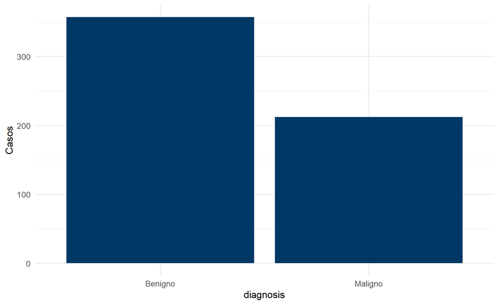

```r
if (resp_categorica) {
  count(datos, .data[[y]]) |> mutate(proporcion = round(n / sum(n), 3)) |> knitr::kable()
  ggplot(datos, aes(x = .data[[y]])) + geom_bar(fill = "#003865") +
    labs(x = y, y = "Casos") + theme_minimal(base_size = 13)
} else {
  ggplot(datos, aes(x = .data[[y]])) + geom_histogram(bins = 30, fill = "#003865") +
    labs(x = y, y = "Casos") + theme_minimal(base_size = 13)
}
```

## 4. Variables numéricas

**Código**

```r
resumen <- datos |>
  select(all_of(num)) |>
  pivot_longer(everything(), names_to = "variable", values_to = "valor") |>
  group_by(variable) |>
  summarise(media = mean(valor, na.rm = TRUE), mediana = median(valor, na.rm = TRUE),
            desv = sd(valor, na.rm = TRUE), min = min(valor, na.rm = TRUE),
            max = max(valor, na.rm = TRUE), asimetria = asimetria(valor), .groups = "drop") |>
  mutate(across(where(is.numeric), ~ round(.x, 3)))
knitr::kable(resumen)
```

| variable | media | mediana | desv | min | max | asimetria |
| --- | --- | --- | --- | --- | --- | --- |
| area_mean | 654.889 | 551.100 | 351.914 | 143.500 | 2501.000 | 1.637 |
| area_se | 40.337 | 24.530 | 45.491 | 6.802 | 542.200 | 5.419 |
| area_worst | 880.583 | 686.500 | 569.357 | 185.200 | 4254.000 | 1.850 |
| compactness_mean | 0.104 | 0.093 | 0.053 | 0.019 | 0.345 | 1.184 |
| compactness_se | 0.025 | 0.020 | 0.018 | 0.002 | 0.135 | 1.892 |
| compactness_worst | 0.254 | 0.212 | 0.157 | 0.027 | 1.058 | 1.466 |
| concave_points_mean | 0.049 | 0.034 | 0.039 | 0.000 | 0.201 | 1.165 |
| concave_points_se | 0.012 | 0.011 | 0.006 | 0.000 | 0.053 | 1.437 |
| concave_points_worst | 0.115 | 0.100 | 0.066 | 0.000 | 0.291 | 0.490 |
| concavity_mean | 0.089 | 0.062 | 0.080 | 0.000 | 0.427 | 1.394 |
| concavity_se | 0.032 | 0.026 | 0.030 | 0.000 | 0.396 | 5.084 |
| concavity_worst | 0.272 | 0.227 | 0.209 | 0.000 | 1.252 | 1.144 |
| fractal_dimension_mean | 0.063 | 0.062 | 0.007 | 0.050 | 0.097 | 1.298 |
| fractal_dimension_se | 0.004 | 0.003 | 0.003 | 0.001 | 0.030 | 3.903 |
| fractal_dimension_worst | 0.084 | 0.080 | 0.018 | 0.055 | 0.208 | 1.654 |
| perimeter_mean | 91.969 | 86.240 | 24.299 | 43.790 | 188.500 | 0.985 |
| perimeter_se | 2.866 | 2.287 | 2.022 | 0.757 | 21.980 | 3.425 |
| perimeter_worst | 107.261 | 97.660 | 33.603 | 50.410 | 251.200 | 1.122 |
| radius_mean | 14.127 | 13.370 | 3.524 | 6.981 | 28.110 | 0.937 |
| radius_se | 0.405 | 0.324 | 0.277 | 0.112 | 2.873 | 3.072 |
| radius_worst | 16.269 | 14.970 | 4.833 | 7.930 | 36.040 | 1.097 |
| smoothness_mean | 0.096 | 0.096 | 0.014 | 0.053 | 0.163 | 0.454 |
| smoothness_se | 0.007 | 0.006 | 0.003 | 0.002 | 0.031 | 2.302 |
| smoothness_worst | 0.132 | 0.131 | 0.023 | 0.071 | 0.223 | 0.413 |
| symmetry_mean | 0.181 | 0.179 | 0.027 | 0.106 | 0.304 | 0.722 |
| symmetry_se | 0.021 | 0.019 | 0.008 | 0.008 | 0.079 | 2.184 |
| symmetry_worst | 0.290 | 0.282 | 0.062 | 0.156 | 0.664 | 1.426 |
| texture_mean | 19.290 | 18.840 | 4.301 | 9.710 | 39.280 | 0.647 |
| texture_se | 1.217 | 1.108 | 0.552 | 0.360 | 4.885 | 1.638 |
| texture_worst | 25.677 | 25.410 | 6.146 | 12.020 | 49.540 | 0.496 |

**Código**

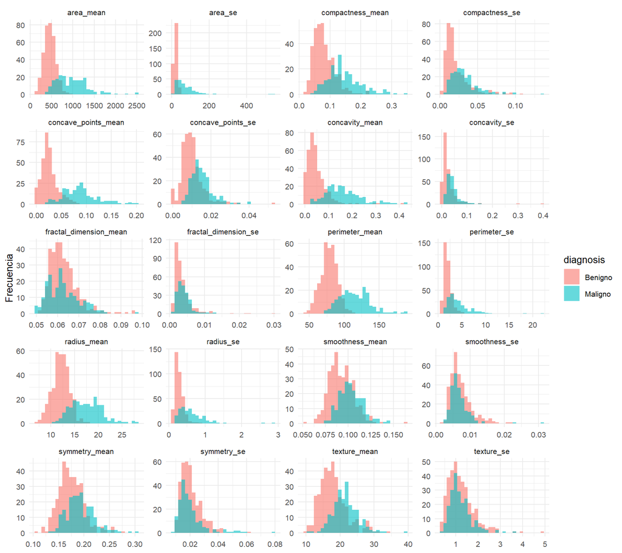

```r
vars_hist <- head(num_var, 20)        # como máximo 20 variables para que el gráfico sea legible
datos |>
  select(all_of(vars_hist), any_of(if (resp_categorica) y)) |>
  pivot_longer(all_of(vars_hist), names_to = "variable", values_to = "valor") |>
  ggplot(aes(x = valor, fill = if (resp_categorica) .data[[y]] else NULL)) +
  geom_histogram(bins = 30, alpha = 0.6, position = "identity") +
  facet_wrap(~ variable, scales = "free", ncol = 4) +
  labs(x = NULL, y = "Frecuencia", fill = y) + theme_minimal(base_size = 10)
```

## 5. Relación con la variable respuesta

Para respuesta categórica con dos grupos se reporta la prueba de Wilcoxon y la d de Cohen; con más de dos grupos, la prueba de Kruskal-Wallis y el tamaño del efecto eta² basado en rangos. Para respuesta numérica, la correlación de Spearman.

**Código**

```r
efecto_var <- function(v) {
  x <- datos[[v]]; g <- datos[[y]]; ok <- !is.na(x) & !is.na(g); x <- x[ok]; g <- g[ok]
  if (!resp_categorica) {
    ct <- suppressWarnings(cor.test(x, g, method = "spearman"))
    return(tibble(variable = v, prueba = "Spearman", p = ct$p.value, efecto = unname(ct$estimate)))
  }
  if (nlevels(droplevels(g)) == 2) {
    lv <- levels(droplevels(g)); a <- x[g == lv[2]]; b <- x[g == lv[1]]
    sp <- sqrt(((length(a) - 1) * var(a) + (length(b) - 1) * var(b)) / (length(a) + length(b) - 2))
    tibble(variable = v, prueba = "Wilcoxon", p = wilcox.test(a, b)$p.value, efecto = (mean(a) - mean(b)) / sp)
  } else {
    kt <- kruskal.test(x, g); k <- nlevels(droplevels(g)); n <- length(x)
    tibble(variable = v, prueba = "Kruskal-Wallis", p = kt$p.value,
           efecto = max(0, (unname(kt$statistic) - k + 1) / (n - k)))
  }
}
efectos <- map_dfr(num_var, efecto_var) |> arrange(desc(abs(efecto)))
efectos |> mutate(p = format.pval(p, digits = 2, eps = 0.001), efecto = round(efecto, 3)) |>
  head(15) |> knitr::kable(caption = "Las 15 variables con mayor tamaño del efecto")
```

Las 15 variables con mayor tamaño del efecto

| variable | prueba | p | efecto |
| --- | --- | --- | --- |
| concave_points_worst | Wilcoxon | <0.001 | 2.693 |
| perimeter_worst | Wilcoxon | <0.001 | 2.598 |
| concave_points_mean | Wilcoxon | <0.001 | 2.545 |
| radius_worst | Wilcoxon | <0.001 | 2.544 |
| perimeter_mean | Wilcoxon | <0.001 | 2.290 |
| area_worst | Wilcoxon | <0.001 | 2.230 |
| radius_mean | Wilcoxon | <0.001 | 2.205 |
| area_mean | Wilcoxon | <0.001 | 2.076 |
| concavity_mean | Wilcoxon | <0.001 | 2.003 |
| concavity_worst | Wilcoxon | <0.001 | 1.812 |
| compactness_mean | Wilcoxon | <0.001 | 1.535 |
| compactness_worst | Wilcoxon | <0.001 | 1.513 |
| radius_se | Wilcoxon | <0.001 | 1.422 |
| perimeter_se | Wilcoxon | <0.001 | 1.382 |
| area_se | Wilcoxon | <0.001 | 1.353 |

**Código**

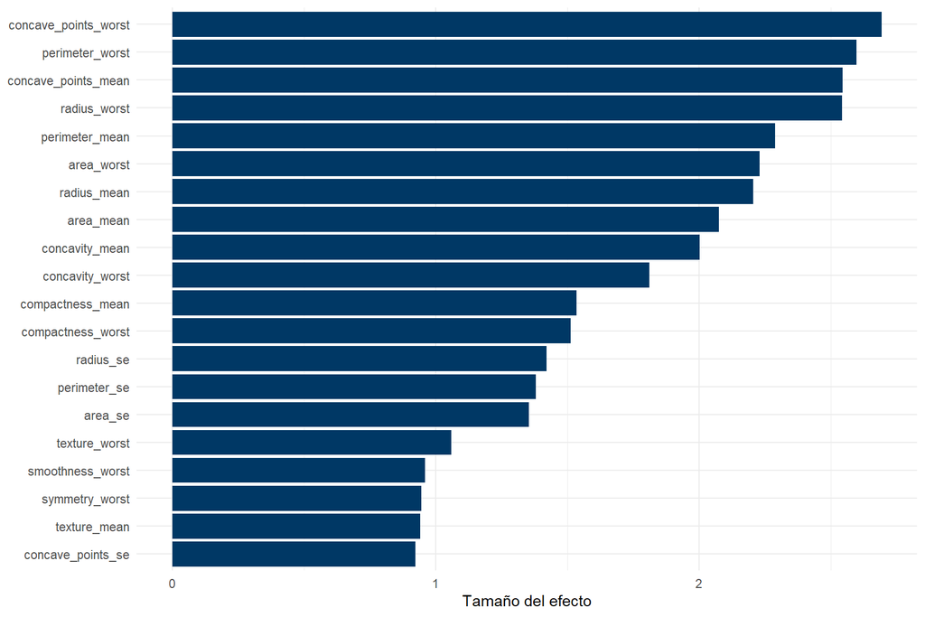

```r
ggplot(head(efectos, 20), aes(x = reorder(variable, abs(efecto)), y = efecto)) +
  geom_col(fill = "#003865") + coord_flip() +
  labs(x = NULL, y = "Tamaño del efecto") + theme_minimal(base_size = 11)
```

## 6. Correlaciones entre predictoras

**Código**

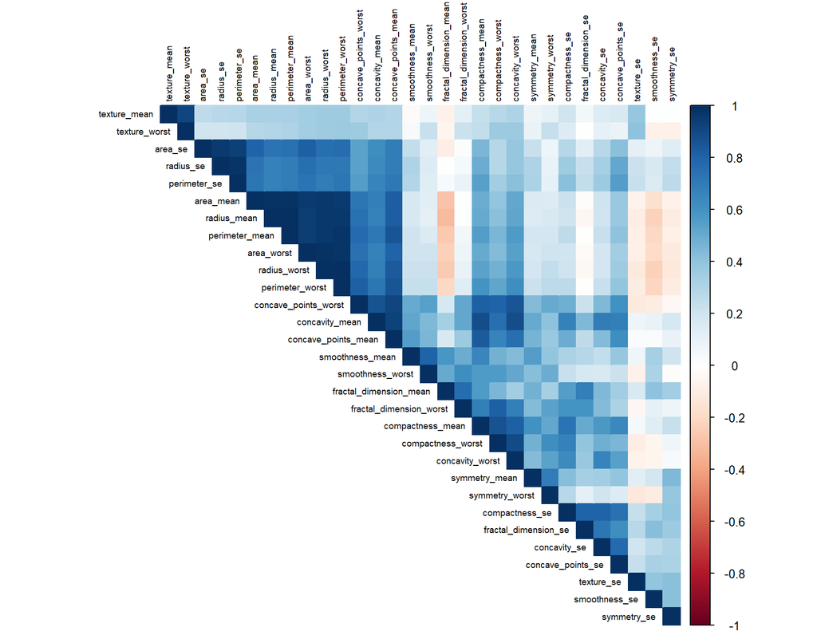

```r
if (length(num_var) >= 2) {
  m <- cor(select(datos, all_of(num_var)), use = "pairwise.complete.obs")
  m[is.na(m)] <- 0
  corrplot(m, method = "color", type = "upper", order = "hclust", tl.col = "black",
           tl.cex = ifelse(length(num_var) > 15, 0.6, 0.9))
}
```

## 7. Variables categóricas

**Código**

```r
if (length(cat_) == 0) cat("El dataset no tiene variables categóricas predictoras.\n")
```

El dataset no tiene variables categóricas predictoras.

**Código**

```r
for (v in cat_) {
  cat("\n**", v, "**\n\n", sep = "")
  print(knitr::kable(count(datos, .data[[v]], sort = TRUE) |> mutate(proporcion = round(n / sum(n), 3)) |> head(15)))
  cat("\n")
}
```

## 8. Alertas automáticas

Estas alertas no son errores: son decisiones que debes tomar y anotar en tu **registro de decisiones**.

**Código**

```r
alertas <- list()
for (i in seq_len(nrow(faltantes))) if (faltantes$prop_faltante[i] > 0.05)
  alertas[[length(alertas) + 1]] <- c("Faltantes", faltantes$variable[i],
    paste0(scales::percent(faltantes$prop_faltante[i], 0.1), " de valores faltantes: decidir imputación o exclusión."))
for (i in seq_len(nrow(resumen))) if (!is.na(resumen$asimetria[i]) && abs(resumen$asimetria[i]) > 1)
  alertas[[length(alertas) + 1]] <- c("Asimetría", resumen$variable[i],
    paste0("asimetría ", resumen$asimetria[i], ": considerar logaritmo o Yeo-Johnson."))
for (i in seq_len(nrow(resumen))) if (!is.na(resumen$desv[i]) && resumen$desv[i] == 0)
  alertas[[length(alertas) + 1]] <- c("Constante", resumen$variable[i], "no varía: no aporta información.")
if (length(num_var) >= 2) {
  m <- cor(select(datos, all_of(num_var)), use = "pairwise.complete.obs"); m[lower.tri(m, diag = TRUE)] <- NA
  pares <- which(abs(m) > 0.9, arr.ind = TRUE)
  for (k in seq_len(nrow(pares))) alertas[[length(alertas) + 1]] <- c("Redundancia",
    paste(rownames(m)[pares[k, 1]], "y", colnames(m)[pares[k, 2]]),
    paste0("correlación ", round(m[pares[k, 1], pares[k, 2]], 2), ": considerar filtro de correlación o PCA."))
}
if (resp_categorica) {
  pmin_ <- min(prop.table(table(datos[[y]])))
  if (pmin_ < 0.3) alertas[[length(alertas) + 1]] <- c("Desbalance", y,
    paste0("la clase minoritaria es el ", scales::percent(pmin_, 0.1), ": usar partición estratificada y métricas por clase."))
}
if (sum(duplicated(datos)) > 0) alertas[[length(alertas) + 1]] <- c("Duplicados", "filas",
  paste(sum(duplicated(datos)), "filas duplicadas: verificar si son errores de registro."))
if (length(alertas) == 0) {
  cat("No se detectaron alertas.")
} else {
  tabla_alertas <- as_tibble(do.call(rbind, alertas), .name_repair = ~ c("Tipo", "Variable", "Qué revisar"))
  knitr::kable(tabla_alertas)
}
```

| Tipo | Variable | Qué revisar |
| --- | --- | --- |
| Asimetría | area_mean | asimetría 1.637: considerar logaritmo o Yeo-Johnson. |
| Asimetría | area_se | asimetría 5.419: considerar logaritmo o Yeo-Johnson. |
| Asimetría | area_worst | asimetría 1.85: considerar logaritmo o Yeo-Johnson. |
| Asimetría | compactness_mean | asimetría 1.184: considerar logaritmo o Yeo-Johnson. |
| Asimetría | compactness_se | asimetría 1.892: considerar logaritmo o Yeo-Johnson. |
| Asimetría | compactness_worst | asimetría 1.466: considerar logaritmo o Yeo-Johnson. |
| Asimetría | concave_points_mean | asimetría 1.165: considerar logaritmo o Yeo-Johnson. |
| Asimetría | concave_points_se | asimetría 1.437: considerar logaritmo o Yeo-Johnson. |
| Asimetría | concavity_mean | asimetría 1.394: considerar logaritmo o Yeo-Johnson. |
| Asimetría | concavity_se | asimetría 5.084: considerar logaritmo o Yeo-Johnson. |
| Asimetría | concavity_worst | asimetría 1.144: considerar logaritmo o Yeo-Johnson. |
| Asimetría | fractal_dimension_mean | asimetría 1.298: considerar logaritmo o Yeo-Johnson. |
| Asimetría | fractal_dimension_se | asimetría 3.903: considerar logaritmo o Yeo-Johnson. |
| Asimetría | fractal_dimension_worst | asimetría 1.654: considerar logaritmo o Yeo-Johnson. |
| Asimetría | perimeter_se | asimetría 3.425: considerar logaritmo o Yeo-Johnson. |
| Asimetría | perimeter_worst | asimetría 1.122: considerar logaritmo o Yeo-Johnson. |
| Asimetría | radius_se | asimetría 3.072: considerar logaritmo o Yeo-Johnson. |
| Asimetría | radius_worst | asimetría 1.097: considerar logaritmo o Yeo-Johnson. |
| Asimetría | smoothness_se | asimetría 2.302: considerar logaritmo o Yeo-Johnson. |
| Asimetría | symmetry_se | asimetría 2.184: considerar logaritmo o Yeo-Johnson. |
| Asimetría | symmetry_worst | asimetría 1.426: considerar logaritmo o Yeo-Johnson. |
| Asimetría | texture_se | asimetría 1.638: considerar logaritmo o Yeo-Johnson. |
| Redundancia | radius_mean y perimeter_mean | correlación 1: considerar filtro de correlación o PCA. |
| Redundancia | radius_mean y area_mean | correlación 0.99: considerar filtro de correlación o PCA. |
| Redundancia | perimeter_mean y area_mean | correlación 0.99: considerar filtro de correlación o PCA. |
| Redundancia | concavity_mean y concave_points_mean | correlación 0.92: considerar filtro de correlación o PCA. |
| Redundancia | radius_se y perimeter_se | correlación 0.97: considerar filtro de correlación o PCA. |
| Redundancia | radius_se y area_se | correlación 0.95: considerar filtro de correlación o PCA. |
| Redundancia | perimeter_se y area_se | correlación 0.94: considerar filtro de correlación o PCA. |
| Redundancia | radius_mean y radius_worst | correlación 0.97: considerar filtro de correlación o PCA. |
| Redundancia | perimeter_mean y radius_worst | correlación 0.97: considerar filtro de correlación o PCA. |
| Redundancia | area_mean y radius_worst | correlación 0.96: considerar filtro de correlación o PCA. |
| Redundancia | texture_mean y texture_worst | correlación 0.91: considerar filtro de correlación o PCA. |
| Redundancia | radius_mean y perimeter_worst | correlación 0.97: considerar filtro de correlación o PCA. |
| Redundancia | perimeter_mean y perimeter_worst | correlación 0.97: considerar filtro de correlación o PCA. |
| Redundancia | area_mean y perimeter_worst | correlación 0.96: considerar filtro de correlación o PCA. |
| Redundancia | radius_worst y perimeter_worst | correlación 0.99: considerar filtro de correlación o PCA. |
| Redundancia | radius_mean y area_worst | correlación 0.94: considerar filtro de correlación o PCA. |
| Redundancia | perimeter_mean y area_worst | correlación 0.94: considerar filtro de correlación o PCA. |
| Redundancia | area_mean y area_worst | correlación 0.96: considerar filtro de correlación o PCA. |
| Redundancia | radius_worst y area_worst | correlación 0.98: considerar filtro de correlación o PCA. |
| Redundancia | perimeter_worst y area_worst | correlación 0.98: considerar filtro de correlación o PCA. |
| Redundancia | concave_points_mean y concave_points_worst | correlación 0.91: considerar filtro de correlación o PCA. |

**TipPrompt listo para copiar: pedir a la IA una propuesta de tratamiento**

Copia la tabla de alertas (solo la tabla: son estadísticos agregados, no datos de personas) y pégala después de este texto:

```
Soy investigador de posgrado. Este es el resumen de alertas del
análisis exploratorio de mi dataset. Para cada alerta, propón un
tratamiento justificado, una alternativa y el efecto esperado, en
formato de tabla: Decisión | Justificación | Alternativa | Efecto.
No inventes información que no esté en la tabla.

[pega aquí la tabla de alertas]
```

Antes de copiar la propuesta a tu registro de decisiones, verifica cada fila con tus datos y con lo visto en clase.